# DATA 605 Final project problem 2

Samriti Malhotra

12/15/2019

```r
# Required libraries
library(MASS)
library(psych)
```

This project is created on the basis of data from Kaggle the House Prices: Advanced Regression Techniques competition on Kaggle https://www.kaggle.com/c/house-prices-advanced-regression-techniques/.

### DATA 605 FINAL PROJECT PROBLEM 2

*Description:*

You are to register for Kaggle.com (free) and compete in the House Prices: Advanced Regression Techniques competition. https://www.kaggle.com/c/house-prices-advanced-regression-techniques . I want you to do the following.

- 5 points. Descriptive and Inferential Statistics. Provide univariate descriptive statistics and appropriate plots for the training data set. Provide a scatterplot matrix for at least two of the independent variables and the dependent variable. Derive a correlation matrix for any three quantitative variables in the dataset. Test the hypotheses that the correlations between each pairwise set of variables is 0 and provide an 80% confidence interval. Discuss the meaning of your analysis. Would you be worried about familywise error? Why or why not?
- 5 points. Linear Algebra and Correlation. Invert your correlation matrix from above. (This is known as the precision matrix and contains variance inflation factors on the diagonal.) Multiply the correlation matrix by the precision matrix, and then multiply the precision matrix by the correlation matrix. Conduct LU decomposition on the matrix.
- 5 points. Calculus-Based Probability & Statistics. Many times, it makes sense to fit a closed form distribution to data. Select a variable in the Kaggle.com training dataset that is skewed to the right, shift it so that the minimum value is absolutely above zero if necessary. Then load the MASS package and run fitdistr to fit an exponential probability density function. (See https://stat.ethz.ch/R-manual/R-devel/library/MASS/html/fitdistr.html ). Find the optimal value of  for this distribution, and then take 1000 samples from this exponential distribution using this value (e.g., $rexp(1000, \lambda))$. Plot a histogram and compare it with a histogram of your original variable. Using the exponential pdf, find the 5th and 95th percentiles using the cumulative distribution function (CDF). Also generate a 95% confidence interval from the empirical data, assuming normality. Finally, provide the empirical 5th percentile and 95th percentile of the data. Discuss.
- 10 points. Modeling. Build some type of multiple regression model and submit your model to the competition board. Provide your complete model summary and results with analysis. Report your Kaggle.com user name and score.

### Import Data

```r
# Import training data
train <- read.csv('train.csv')

# General size of the data set
dim(train)
```

```
## [1] 1460   81
```

As per common understanding sale price correlate with `LotArea` . We will base our analysis on this and see the importance of LotFrontage and other factors which help buyer get additional space.

```r
summary(train$LotFrontage)
```

```
##    Min. 1st Qu.  Median    Mean 3rd Qu.    Max.    NA's
##   21.00   59.00   69.00   70.05   80.00  313.00     259
```

As we can see there are 259 NA’s out of 1460 observations.In our analysis I lets assign variable $X$ to `LotFrontage` and variable $Y$ to `SalePrice`.

```r
X <- train$LotFrontage
Y <- train$SalePrice
```

### Probability

Due the fact that `LotFrontage`, has some NA’s values we are removing all observations with value NA.

```r
probdata <- train[, c("LotFrontage", "SalePrice")]
probdata <- probdata[!is.na(probdata$LotFrontage),]

summary(probdata$LotFrontage)
```

```
##    Min. 1st Qu.  Median    Mean 3rd Qu.    Max.
##   21.00   59.00   69.00   70.05   80.00  313.00
```

```r
summary(probdata$SalePrice)
```

```
##    Min. 1st Qu.  Median    Mean 3rd Qu.    Max.
##   34900  127500  159500  180771  213500  755000
```

```r
# First quartile of X variable
x <- quantile(probdata$LotFrontage)[2]
# Second quartile / median of Y variable
y <- median(probdata$SalePrice)
```

```r
t <- c(nrow(probdata[probdata$LotFrontage<x & probdata$SalePrice<y,]),
       nrow(probdata[probdata$LotFrontage<x & probdata$SalePrice==y,]),
       nrow(probdata[probdata$LotFrontage<x & probdata$SalePrice>y,]))
t <- rbind(t,c(nrow(probdata[probdata$LotFrontage==x & probdata$SalePrice<y,]),
               nrow(probdata[probdata$LotFrontage==x & probdata$SalePrice==y,]),
               nrow(probdata[probdata$LotFrontage==x & probdata$SalePrice>y,])))
t <- rbind(t,c(nrow(probdata[probdata$LotFrontage>x & probdata$SalePrice<y,]),
               nrow(probdata[probdata$LotFrontage>x & probdata$SalePrice==y,]),
               nrow(probdata[probdata$LotFrontage>x & probdata$SalePrice>y,])))
t <- cbind(t, t[,1] + t[,2] + t[,3])
t <- rbind(t, t[1,] + t[2,] + t[3,])
colnames(t) <- c("Y<y", "Y=y", "Y>y", "Total")
rownames(t) <- c("X<x", "X=x", "X>x", "Total")
knitr::kable(t)
```

|  | Y<y | Y=y | Y>y | Total |
| --- | --- | --- | --- | --- |
| X<x | 190 | 0 | 101 | 291 |
| X=x | 5 | 0 | 8 | 13 |
| X>x | 405 | 3 | 489 | 897 |
| Total | 600 | 3 | 598 | 1201 |

1. $P(X>x | Y>y)=\frac{489}{598} \approx 0.8177$
2. $P(X>x\ and\ Y>y) = \frac{489}{1201} \approx 0.4072$
3. $P(X<x | Y>y)=\frac{101}{598} \approx 0.1689$

Calculating Probability using table for further understanding .

```r
knitr::kable(round(t/1201,4))
```

|  | Y<y | Y=y | Y>y | Total |
| --- | --- | --- | --- | --- |
| X<x | 0.1582 | 0.0000 | 0.0841 | 0.2423 |
| X=x | 0.0042 | 0.0000 | 0.0067 | 0.0108 |
| X>x | 0.3372 | 0.0025 | 0.4072 | 0.7469 |
| Total | 0.4996 | 0.0025 | 0.4979 | 1.0000 |

Consider probability (a) above: $P(X>x | Y>y)=0.8177$. $P(X>x)=0.7469$.

$P(X>x | Y>y) \ne P(X>x)$, these events are **not independent**.

#### Chi-squared Test to Evaluate Null Hypothesis

```r
chisq.test(table(probdata$LotFrontage>x, probdata$SalePrice>y))
```

```
##
##  Pearson's Chi-squared test with Yates' continuity correction
##
## data:  table(probdata$LotFrontage > x, probdata$SalePrice > y)
## X-squared = 30.881, df = 1, p-value = 0.00000002743
```

As we see p-value which is nearly zero. Hence, we may reject the null hypothesis and agree that both events are not independent.

### REQUIREMENT 1, Descriptive and Inferential Statistics

Descriptive and Inferential Statistics. Provide univariate descriptive statistics and appropriate plots for the training data set. Provide a scatterplot matrix for at least two of the independent variables and the dependent variable. Derive a correlation matrix for any three quantitative variables in the dataset. Test the hypotheses that the correlations between each pairwise set of variables is 0 and provide an 80% confidence interval. Discuss the meaning of your analysis. Would you be worried about familywise error? Why or why not?

To be able to effectivelly address this requirements I have decided to get:

Get some basic statistics about the `LotFrontage` variable.

```r
summary(X)
```

```
##    Min. 1st Qu.  Median    Mean 3rd Qu.    Max.    NA's
##   21.00   59.00   69.00   70.05   80.00  313.00     259
```

There are 1,201 valid observations between a very small/narrow lot of 21 feet and large lot of 313 feet. Average frontage is 70.05 feet.

Basic statistics about the `SalePrice` variable.

```r
summary(Y)
```

```
##    Min. 1st Qu.  Median    Mean 3rd Qu.    Max.
##   34900  129975  163000  180921  214000  755000
```

Sale price is available for 1460 observations. It ranges from $35,000 to over $750,000. Average sale price is $180,921.

Evaluating few plots.

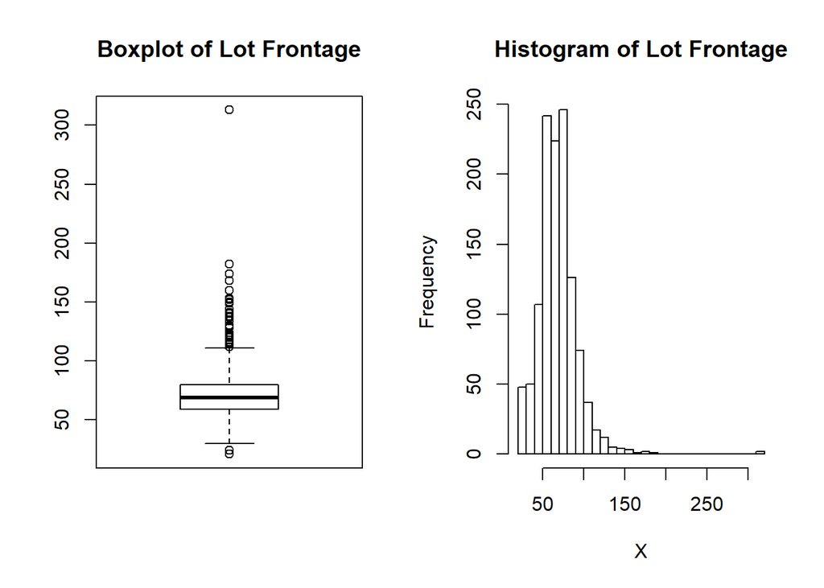

```r
par(mfrow=c(1,2))
boxplot(X, main="Boxplot of Lot Frontage")
hist(X, breaks=40, main="Histogram of Lot Frontage")
```

From our observation of `LotFrontage` boxplot and histogram, we can see that there are outliers and distibution is right-skewed.

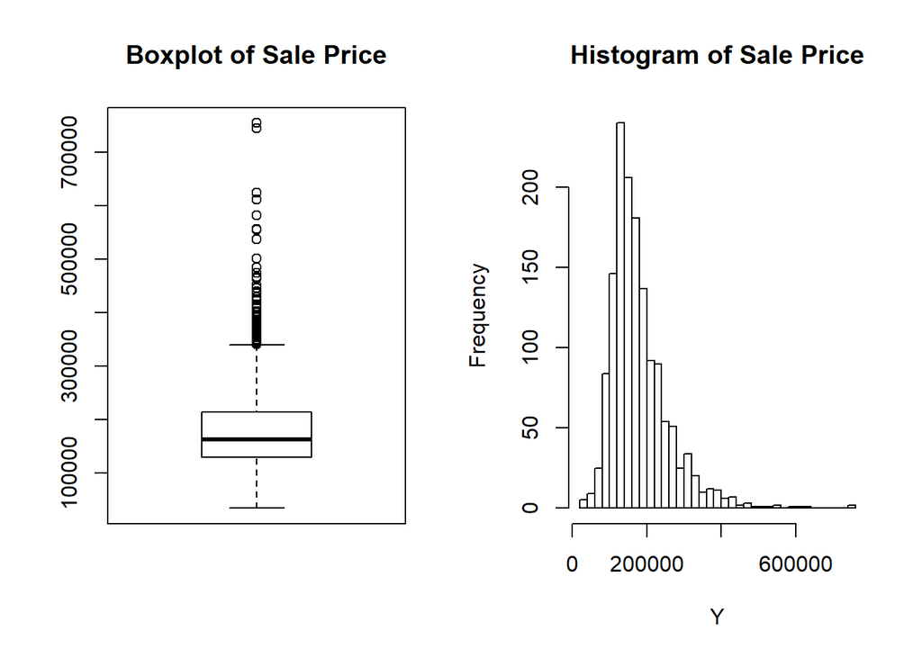

```r
par(mfrow=c(1,2))
boxplot(Y, main="Boxplot of Sale Price")
hist(Y, breaks=40, main="Histogram of Sale Price")
```

Distribution of `SalePrice` is close to the distribution of `LotFrontage`.

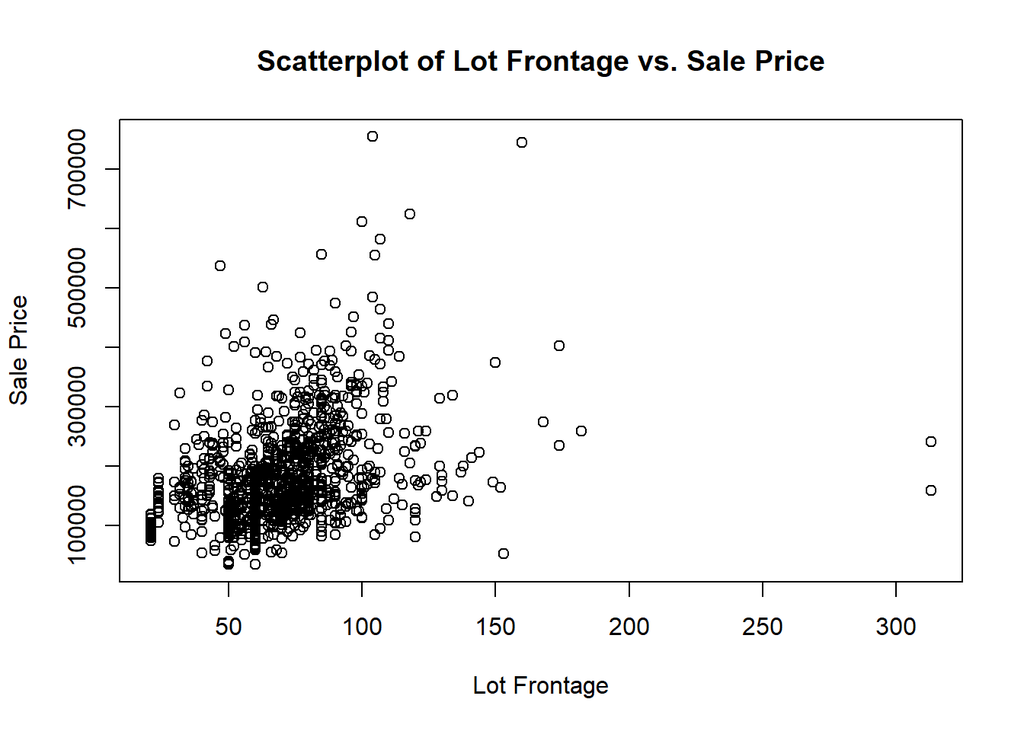

```r
plot(X, Y, xlab="Lot Frontage", ylab="Sale Price",
     main="Scatterplot of Lot Frontage vs. Sale Price")
```

As we observe from the scatter plot, there is no clear correlation. To further identify we decide to build and analyze a linear regression model.

```r
lm1 <- lm(Y ~ X)
summary(lm1)
```

```
##
## Call:
## lm(formula = Y ~ X)
##
## Residuals:
##     Min      1Q  Median      3Q     Max
## -314258  -48878  -19402   33290  533217
##
## Coefficients:
##             Estimate Std. Error t value Pr(>|t|)
## (Intercept) 96149.04    6881.97   13.97   <2e-16 ***
## X            1208.02      92.83   13.01   <2e-16 ***
## ---
## Signif. codes:  0 '***' 0.001 '**' 0.01 '*' 0.05 '.' 0.1 ' ' 1
##
## Residual standard error: 78090 on 1199 degrees of freedom
##   (259 observations deleted due to missingness)
## Multiple R-squared:  0.1238, Adjusted R-squared:  0.123
## F-statistic: 169.4 on 1 and 1199 DF,  p-value: < 2.2e-16
```

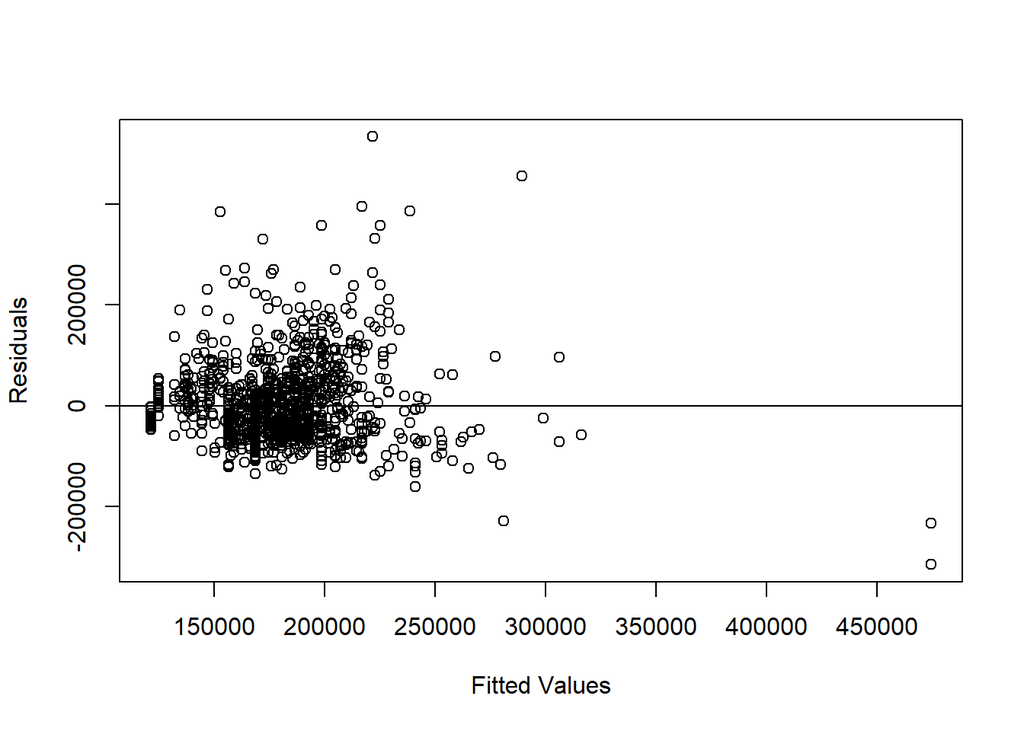

```r
plot(lm1$fitted.values, lm1$residuals,
     xlab="Fitted Values", ylab="Residuals")
abline(h=0)
```

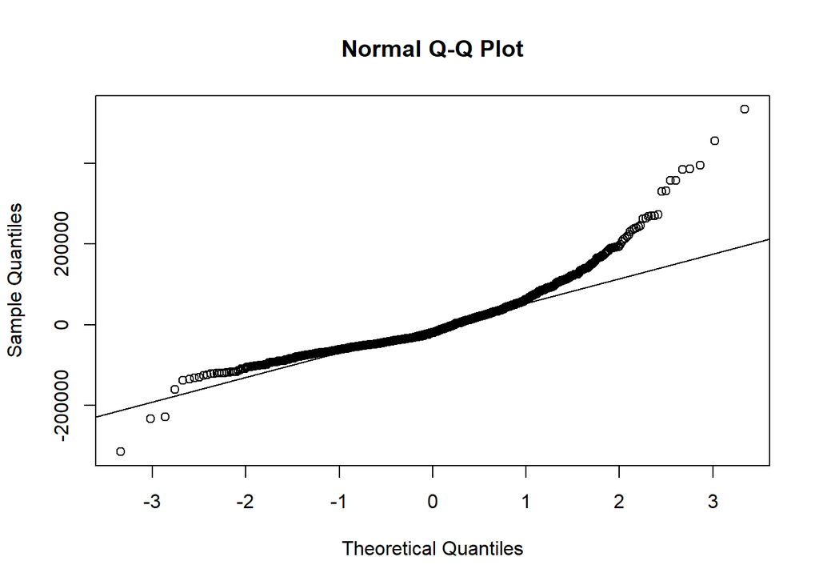

```r
qqnorm(lm1$residuals); qqline(lm1$residuals)
```

#### Box Cox Transformation

```r
bc <- boxcox(lm1)
```

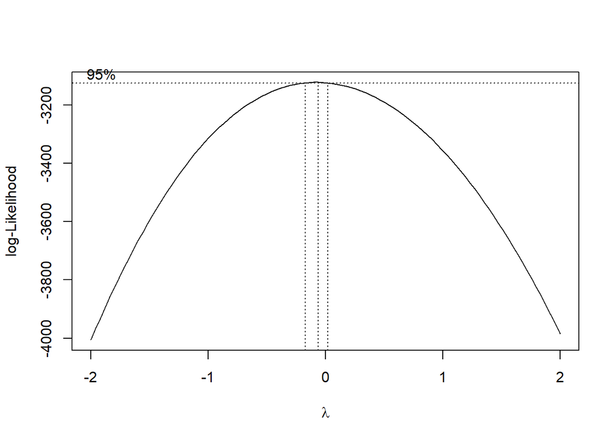

```r
(lambda <- bc$x[which.max(bc$y)])
```

```
## [1] -0.06060606
```

We can see optimal $\lambda$ value is close to 0. In fact 0 is included in the 95% confidence interval.

### Requirements 2, (Linear Algebra and Correlation):

Invert your correlation matrix from above. (This is known as the precision matrix and contains variance inflation factors on the diagonal.) Multiply the correlation matrix by the precision matrix, and then multiply the precision matrix by the correlation matrix. Conduct LU decomposition on the matrix.

In this section we are selecting following 4 variables from the data and build a correlation matrix:

- `TotalBsmtSF`: Total square feet of basement area
- `MoSold`: Month sold
- `OverallCond`: Rates the overall condition of the house (from *1-Very Poor* to *10-Very Excellent*)
- `SalePrice`: Sale price

```r
cordata <- train[, c("TotalBsmtSF", "MoSold", "OverallCond", "SalePrice")]
cormatrix <- cor(cordata)
round(cormatrix,2)
```

```
##             TotalBsmtSF MoSold OverallCond SalePrice
## TotalBsmtSF        1.00   0.01       -0.17      0.61
## MoSold             0.01   1.00        0.00      0.05
## OverallCond       -0.17   0.00        1.00     -0.08
## SalePrice          0.61   0.05       -0.08      1.00
```

Above we observed that basement correlates with the sale price , meaning larger basement suggests larger house and higher sale price.

Inverting the correlation matrix to get the precision matrix.

```r
precmatrix <- solve(cormatrix)
round(precmatrix,2)
```

```
##             TotalBsmtSF MoSold OverallCond SalePrice
## TotalBsmtSF        1.64   0.03        0.20     -0.99
## MoSold             0.03   1.00        0.00     -0.06
## OverallCond        0.20   0.00        1.03     -0.05
## SalePrice         -0.99  -0.06       -0.05      1.61
```

```r
round(diag(precmatrix),2)
```

```
## TotalBsmtSF      MoSold OverallCond   SalePrice
##        1.64        1.00        1.03        1.61
```

From the observation `TotalBsmtSF` and `SalePrice` have moderate correlation.

**identity** matrix can be confirmed below by taking the general principle of $[Precision] = [Correlation]^{-1}$, then $[Precision]\times[Correlation]$.

```r
round(cormatrix %*% precmatrix,4)
```

```
##             TotalBsmtSF MoSold OverallCond SalePrice
## TotalBsmtSF           1      0           0         0
## MoSold                0      1           0         0
## OverallCond           0      0           1         0
## SalePrice             0      0           0         1
```

```r
round(precmatrix %*% cormatrix,4) == round(cormatrix %*% precmatrix,4)
```

```
##             TotalBsmtSF MoSold OverallCond SalePrice
## TotalBsmtSF        TRUE   TRUE        TRUE      TRUE
## MoSold             TRUE   TRUE        TRUE      TRUE
## OverallCond        TRUE   TRUE        TRUE      TRUE
## SalePrice          TRUE   TRUE        TRUE      TRUE
```

### Requirement 3, Calculus-Based Probability and Statistics;

For this section we decide to see actual distribution of `LotFrontage` against gamma distribution using the `fitdistr` method of the `MASS` library.

```r
# Remove NAs
X <- X[!is.na(X)]

# Fitting of univariate distribution
(fd <- fitdistr(X, "gamma"))
```

```
##       shape         rate
##   8.760347516   0.125058578
##  (0.350766218) (0.005153394)
```

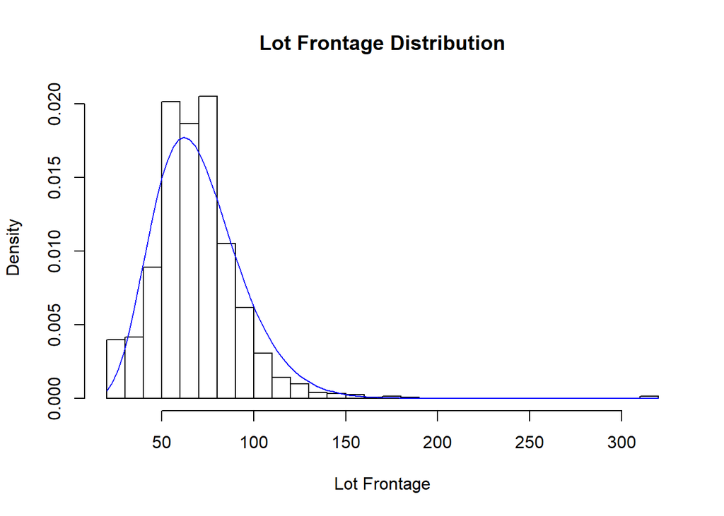

```r
# Actual vs simulated distribution
hist(X, breaks=40, prob=TRUE, xlab="Lot Frontage",
     main="Lot Frontage Distribution")
curve(dgamma(x, shape = fd$estimate['shape'], rate = fd$estimate['rate']),
      col="blue", add=TRUE)
```

As we can see it look a good fit .

To see if we can get a better option I will be using another distribution focused on `fitdistr`.

```r
distributions <- c("cauchy", "exponential", "gamma", "geometric", "log-normal", "lognormal",
                   "logistic", "negative binomial", "normal", "Poisson", "t", "weibull")
logliks <- c()
for (d in distributions) {
  logliks <- c(logliks, fitdistr(X, d)$loglik)
}

logtable <- as.data.frame(cbind(distributions, logliks))
knitr::kable(logtable[order(logtable$logliks),],
             row.names=FALSE, col.names=c("Distribution", "Log-Likelihood"))
```

| Distribution | Log-Likelihood |
| --- | --- |
| t | -5396.744870698 |
| logistic | -5419.29549094738 |
| negative binomial | -5453.90319970878 |
| gamma | -5457.20013064461 |
| log-normal | -5485.89040512713 |
| lognormal | -5485.89040512713 |
| cauchy | -5519.19936068162 |
| normal | -5534.6532040307 |
| weibull | -5559.41415360689 |
| exponential | -6304.29962283632 |
| geometric | -6312.83157278274 |
| Poisson | -8309.11486947954 |

### Requirement 4 (Modeling)

Build some type of multiple regression model and submit your model to the competition board. Provide your complete model summary and results with analysis. Report your Kaggle.com user name and score.

#### Description of steps that are taken in modeling and the final outcome

The following are key steps taken in building the model:

1. Categorical variables were converted to numerical values.
2. Due to the number of missing data we have eliminated various variables to reach at a conclusive outcome.
3. Target variable, `SalePrice`, was log-transformed to bring it to the scale of other variables.

#### Modeling Work

```r
# Read test data and add SalePrice column
test <- read.csv('test.csv')
test <- cbind(test, SalePrice=rep(0,nrow(test)))

# Get training data and review summary statistics
md <- train
summary(md)
```

```
##        Id           MSSubClass       MSZoning     LotFrontage
##  Min.   :   1.0   Min.   : 20.0   C (all):  10   Min.   : 21.00
##  1st Qu.: 365.8   1st Qu.: 20.0   FV     :  65   1st Qu.: 59.00
##  Median : 730.5   Median : 50.0   RH     :  16   Median : 69.00
##  Mean   : 730.5   Mean   : 56.9   RL     :1151   Mean   : 70.05
##  3rd Qu.:1095.2   3rd Qu.: 70.0   RM     : 218   3rd Qu.: 80.00
##  Max.   :1460.0   Max.   :190.0                  Max.   :313.00
##                                                  NA's   :259
##     LotArea        Street      Alley      LotShape  LandContour
##  Min.   :  1300   Grvl:   6   Grvl:  50   IR1:484   Bnk:  63
##  1st Qu.:  7554   Pave:1454   Pave:  41   IR2: 41   HLS:  50
##  Median :  9478               NA's:1369   IR3: 10   Low:  36
##  Mean   : 10517                           Reg:925   Lvl:1311
##  3rd Qu.: 11602
##  Max.   :215245
##
##   Utilities      LotConfig    LandSlope   Neighborhood   Condition1
##  AllPub:1459   Corner : 263   Gtl:1382   NAmes  :225   Norm   :1260
##  NoSeWa:   1   CulDSac:  94   Mod:  65   CollgCr:150   Feedr  :  81
##                FR2    :  47   Sev:  13   OldTown:113   Artery :  48
##                FR3    :   4              Edwards:100   RRAn   :  26
##                Inside :1052              Somerst: 86   PosN   :  19
##                                          Gilbert: 79   RRAe   :  11
##                                          (Other):707   (Other):  15
##    Condition2     BldgType      HouseStyle   OverallQual
##  Norm   :1445   1Fam  :1220   1Story :726   Min.   : 1.000
##  Feedr  :   6   2fmCon:  31   2Story :445   1st Qu.: 5.000
##  Artery :   2   Duplex:  52   1.5Fin :154   Median : 6.000
##  PosN   :   2   Twnhs :  43   SLvl   : 65   Mean   : 6.099
##  RRNn   :   2   TwnhsE: 114   SFoyer : 37   3rd Qu.: 7.000
##  PosA   :   1                 1.5Unf : 14   Max.   :10.000
##  (Other):   2                 (Other): 19
##   OverallCond      YearBuilt     YearRemodAdd    RoofStyle
##  Min.   :1.000   Min.   :1872   Min.   :1950   Flat   :  13
##  1st Qu.:5.000   1st Qu.:1954   1st Qu.:1967   Gable  :1141
##  Median :5.000   Median :1973   Median :1994   Gambrel:  11
##  Mean   :5.575   Mean   :1971   Mean   :1985   Hip    : 286
##  3rd Qu.:6.000   3rd Qu.:2000   3rd Qu.:2004   Mansard:   7
##  Max.   :9.000   Max.   :2010   Max.   :2010   Shed   :   2
##
```

[output cut: 89 more lines]

```
##  GdPrv:  59   Gar2:   2   Min.   :    0.00   Min.   : 1.000
##  GdWo :  54   Othr:   2   1st Qu.:    0.00   1st Qu.: 5.000
##  MnPrv: 157   Shed:  49   Median :    0.00   Median : 6.000
##  MnWw :  11   TenC:   1   Mean   :   43.49   Mean   : 6.322
##  NA's :1179   NA's:1406   3rd Qu.:    0.00   3rd Qu.: 8.000
##                           Max.   :15500.00   Max.   :12.000
##
##      YrSold        SaleType    SaleCondition    SalePrice
##  Min.   :2006   WD     :1267   Abnorml: 101   Min.   : 34900
##  1st Qu.:2007   New    : 122   AdjLand:   4   1st Qu.:129975
##  Median :2008   COD    :  43   Alloca :  12   Median :163000
##  Mean   :2008   ConLD  :   9   Family :  20   Mean   :180921
##  3rd Qu.:2009   ConLI  :   5   Normal :1198   3rd Qu.:214000
##  Max.   :2010   ConLw  :   5   Partial: 125   Max.   :755000
##                 (Other):   9
```

```r
# Combine with testing data to do global replacements
md <- rbind(md, test)

# Eliminate features with limited or missing data
md <- subset(md, select=-c(Street, Alley, LandContour, Utilities,
                           LandSlope, Condition2, MasVnrArea, Heating,
                           BsmtFinSF2, X2ndFlrSF, LowQualFinSF, BsmtFullBath,
                           BsmtHalfBath, HalfBath, PoolQC, PoolArea, MiscVal,
                           MiscFeature, Fence, ScreenPorch, Fireplaces,
                           EnclosedPorch, MoSold, YrSold))
```

After eliminating incomplte data we have the following columns that are relevant for our analysis.

```r
colnames(md)
```

```
##  [1] "Id"            "MSSubClass"    "MSZoning"      "LotFrontage"
##  [5] "LotArea"       "LotShape"      "LotConfig"     "Neighborhood"
##  [9] "Condition1"    "BldgType"      "HouseStyle"    "OverallQual"
## [13] "OverallCond"   "YearBuilt"     "YearRemodAdd"  "RoofStyle"
## [17] "RoofMatl"      "Exterior1st"   "Exterior2nd"   "MasVnrType"
## [21] "ExterQual"     "ExterCond"     "Foundation"    "BsmtQual"
## [25] "BsmtCond"      "BsmtExposure"  "BsmtFinType1"  "BsmtFinSF1"
## [29] "BsmtFinType2"  "BsmtUnfSF"     "TotalBsmtSF"   "HeatingQC"
## [33] "CentralAir"    "Electrical"    "X1stFlrSF"     "GrLivArea"
## [37] "FullBath"      "BedroomAbvGr"  "KitchenAbvGr"  "KitchenQual"
## [41] "TotRmsAbvGrd"  "Functional"    "FireplaceQu"   "GarageType"
## [45] "GarageYrBlt"   "GarageFinish"  "GarageCars"    "GarageArea"
## [49] "GarageQual"    "GarageCond"    "PavedDrive"    "WoodDeckSF"
## [53] "OpenPorchSF"   "X3SsnPorch"    "SaleType"      "SaleCondition"
## [57] "SalePrice"
```

```r
md <- subset(md, select=-c(LotShape, YearRemodAdd, BsmtExposure,
                           BsmtFinType2, TotalBsmtSF, TotRmsAbvGrd,
                           FireplaceQu, GarageYrBlt, GarageCars))
```

As we can see categorical variables were converted to numerical values and NAs are replaced with zeros.

```r
md$Neighborhood <- as.integer(factor(md$Neighborhood))
md$MSZoning <- as.integer(factor(md$MSZoning))
md$LotConfig <- as.integer(factor(md$LotConfig))
md$Condition1 <- as.integer(factor(md$Condition1))
md$BldgType <- as.integer(factor(md$BldgType))
md$HouseStyle <- as.integer(factor(md$HouseStyle))
md$RoofStyle <- as.integer(factor(md$RoofStyle))
md$RoofMatl <- as.integer(factor(md$RoofMatl))
md$Exterior1st <- as.integer(factor(md$Exterior1st))
md$Exterior2nd <- as.integer(factor(md$Exterior2nd))
md$MasVnrType <- as.integer(factor(md$MasVnrType))
md$ExterQual <- as.integer(factor(md$ExterQual))
md$ExterCond <- as.integer(factor(md$ExterCond))
md$BsmtQual <- as.integer(factor(md$BsmtQual))
md$BsmtCond <- as.integer(factor(md$BsmtCond))
md$Electrical <- as.integer(factor(md$Electrical))
md$KitchenQual <- as.integer(factor(md$KitchenQual))
md$Functional <- as.integer(factor(md$Functional))
md$GarageType <- as.integer(factor(md$GarageType))
md$GarageFinish <- as.integer(factor(md$GarageFinish))
md$GarageCond <- as.integer(factor(md$GarageCond))
md$BsmtFinType1 <- as.integer(factor(md$BsmtFinType1))
md$PavedDrive <- as.integer(factor(md$PavedDrive))
md$SaleType <- as.integer(factor(md$SaleType))
md$SaleCondition <- as.integer(factor(md$SaleCondition))
md$Foundation <- as.integer(factor(md$Foundation))
md$HeatingQC <- as.integer(factor(md$HeatingQC))
md$GarageQual <- as.integer(factor(md$GarageQual))

md[is.na(md)] <- 0
```

Below we have Log-transform sales price in the training set for the purpose of training and testing sets .

```r
test <- md[md$SalePrice==0,]
md <- md[md$SalePrice>0,]

md$SalePrice <- log(md$SalePrice)

# Remove ID column from training data
md <- subset(md, select=-c(Id))

# Build initial model with all fields
sale_lm <- lm(SalePrice ~ . , data=md)
summary(sale_lm)
```

```
##
## Call:
## lm(formula = SalePrice ~ ., data = md)
##
## Residuals:
##      Min       1Q   Median       3Q      Max
## -2.22119 -0.06729  0.00481  0.07152  0.57745
##
## Coefficients:
##                    Estimate    Std. Error t value       Pr(>|t|)
## (Intercept)    6.8245491893  0.5866086932  11.634        < 2e-16 ***
## MSSubClass    -0.0001499385  0.0002062562  -0.727       0.467375
## MSZoning      -0.0113649010  0.0069254126  -1.641       0.101011
## LotFrontage   -0.0003569532  0.0001241554  -2.875       0.004100 **
## LotArea        0.0000021439  0.0000004345   4.934 0.000000900481 ***
## LotConfig     -0.0024205201  0.0024645119  -0.982       0.326194
## Neighborhood   0.0006136411  0.0007167650   0.856       0.392073
## Condition1     0.0023177047  0.0046531586   0.498       0.618496
## BldgType      -0.0141640724  0.0067806927  -2.089       0.036897 *
## HouseStyle    -0.0006281607  0.0029067379  -0.216       0.828937
## OverallQual    0.0841413908  0.0053662685  15.680        < 2e-16 ***
## OverallCond    0.0377076166  0.0043970790   8.576        < 2e-16 ***
## YearBuilt      0.0018044387  0.0003013258   5.988 0.000000002685 ***
## RoofStyle      0.0054973694  0.0051203865   1.074       0.283175
## RoofMatl       0.0142457900  0.0068518449   2.079       0.037787 *
## Exterior1st   -0.0044228762  0.0024047674  -1.839       0.066094 .
## Exterior2nd    0.0051075939  0.0021846799   2.338       0.019531 *
## MasVnrType     0.0066061971  0.0063761285   1.036       0.300341
## ExterQual     -0.0071693436  0.0089708972  -0.799       0.424322
## ExterCond      0.0126996544  0.0057910534   2.193       0.028471 *
## Foundation     0.0031759507  0.0076838702   0.413       0.679430
## BsmtQual      -0.0082611036  0.0057893473  -1.427       0.153816
## BsmtCond       0.0190941148  0.0056795398   3.362       0.000795 ***
## BsmtFinType1  -0.0070904709  0.0028044244  -2.528       0.011569 *
## BsmtFinSF1     0.0000453185  0.0000175868   2.577       0.010071 *
## BsmtUnfSF     -0.0000022554  0.0000185693  -0.121       0.903347
## HeatingQC     -0.0111870208  0.0027751580  -4.031 0.000058470318 ***
## CentralAirY    0.0890470168  0.0196187285   4.539 0.000006135533 ***
## Electrical     0.0022272879  0.0041701417   0.534       0.593354
## X1stFlrSF      0.0000761228  0.0000222085   3.428       0.000626 ***
```

[output cut: 8 more lines]

```
## GarageArea     0.0001610149  0.0000294003   5.477 0.000000051244 ***
## GarageQual     0.0045933999  0.0076827806   0.598       0.550014
## GarageCond     0.0162230798  0.0079750856   2.034       0.042116 *
## PavedDrive     0.0201491987  0.0095357241   2.113       0.034774 *
## WoodDeckSF     0.0001147680  0.0000340577   3.370       0.000772 ***
## OpenPorchSF   -0.0000148112  0.0000654207  -0.226       0.820923
## X3SsnPorch     0.0001175080  0.0001348675   0.871       0.383747
## SaleType      -0.0005982979  0.0026325612  -0.227       0.820248
## SaleCondition  0.0238176500  0.0038100777   6.251 0.000000000538 ***
## ---
## Signif. codes:  0 '***' 0.001 '**' 0.01 '*' 0.05 '.' 0.1 ' ' 1
##
## Residual standard error: 0.1486 on 1413 degrees of freedom
## Multiple R-squared:  0.866,  Adjusted R-squared:  0.8617
## F-statistic: 198.6 on 46 and 1413 DF,  p-value: < 2.2e-16
```

To have more clearer understanding we have Optimized the model using `stepAIC` method.

```r
step_lm <- stepAIC(sale_lm, trace=FALSE)
summary(step_lm)
```

```
##
## Call:
## lm(formula = SalePrice ~ MSZoning + LotFrontage + LotArea + BldgType +
##     OverallQual + OverallCond + YearBuilt + RoofMatl + Exterior1st +
##     Exterior2nd + ExterCond + BsmtQual + BsmtCond + BsmtFinType1 +
##     BsmtFinSF1 + HeatingQC + CentralAir + X1stFlrSF + GrLivArea +
##     FullBath + KitchenQual + Functional + GarageType + GarageFinish +
##     GarageArea + GarageCond + PavedDrive + WoodDeckSF + SaleCondition,
##     data = md)
##
## Residuals:
##      Min       1Q   Median       3Q      Max
## -2.24086 -0.06623  0.00565  0.07351  0.58820
##
## Coefficients:
##                    Estimate    Std. Error t value          Pr(>|t|)
## (Intercept)    6.6009060484  0.5122756066  12.885           < 2e-16 ***
## MSZoning      -0.0135208963  0.0066378388  -2.037          0.041840 *
## LotFrontage   -0.0003484392  0.0001218122  -2.860          0.004292 **
## LotArea        0.0000021492  0.0000004291   5.009 0.000000616289858 ***
## BldgType      -0.0212957859  0.0036613594  -5.816 0.000000007408787 ***
## OverallQual    0.0863505864  0.0050137850  17.223           < 2e-16 ***
## OverallCond    0.0382499520  0.0042948768   8.906           < 2e-16 ***
## YearBuilt      0.0019266454  0.0002610902   7.379 0.000000000000269 ***
## RoofMatl       0.0128618101  0.0067259235   1.912          0.056041 .
## Exterior1st   -0.0042612207  0.0023702750  -1.798          0.072424 .
## Exterior2nd    0.0047060558  0.0021372511   2.202          0.027830 *
## ExterCond      0.0122796320  0.0057027593   2.153          0.031464 *
## BsmtQual      -0.0085045662  0.0054468491  -1.561          0.118657
## BsmtCond       0.0185608151  0.0054753119   3.390          0.000718 ***
## BsmtFinType1  -0.0072791564  0.0026341330  -2.763          0.005794 **
## BsmtFinSF1     0.0000450241  0.0000118126   3.812          0.000144 ***
## HeatingQC     -0.0113964832  0.0027047614  -4.213 0.000026719179231 ***
## CentralAirY    0.0937487472  0.0190062531   4.933 0.000000906709975 ***
## X1stFlrSF      0.0000842612  0.0000148898   5.659 0.000000018369101 ***
## GrLivArea      0.0002151555  0.0000126530  17.004           < 2e-16 ***
## FullBath       0.0268033002  0.0107570156   2.492          0.012826 *
## KitchenQual   -0.0312929251  0.0061043433  -5.126 0.000000335857780 ***
## Functional     0.0159773907  0.0042064430   3.798          0.000152 ***
## GarageType    -0.0051096355  0.0028169164  -1.814          0.069901 .
## GarageFinish  -0.0125104973  0.0063597975  -1.967          0.049362 *
## GarageArea     0.0001617009  0.0000284126   5.691 0.000000015284918 ***
## GarageCond     0.0200256677  0.0049076281   4.081 0.000047417532552 ***
## PavedDrive     0.0205367649  0.0094337381   2.177          0.029647 *
## WoodDeckSF     0.0001163306  0.0000336756   3.454          0.000568 ***
## SaleCondition  0.0242121985  0.0036888630   6.564 0.000000000073266 ***
## ---
## Signif. codes:  0 '***' 0.001 '**' 0.01 '*' 0.05 '.' 0.1 ' ' 1
##
## Residual standard error: 0.1483 on 1430 degrees of freedom
## Multiple R-squared:  0.8649, Adjusted R-squared:  0.8622
## F-statistic: 315.8 on 29 and 1430 DF,  p-value: < 2.2e-16
```

$R^2$ is over 0.86 which seems like a good fit.

Residuals are checked below .

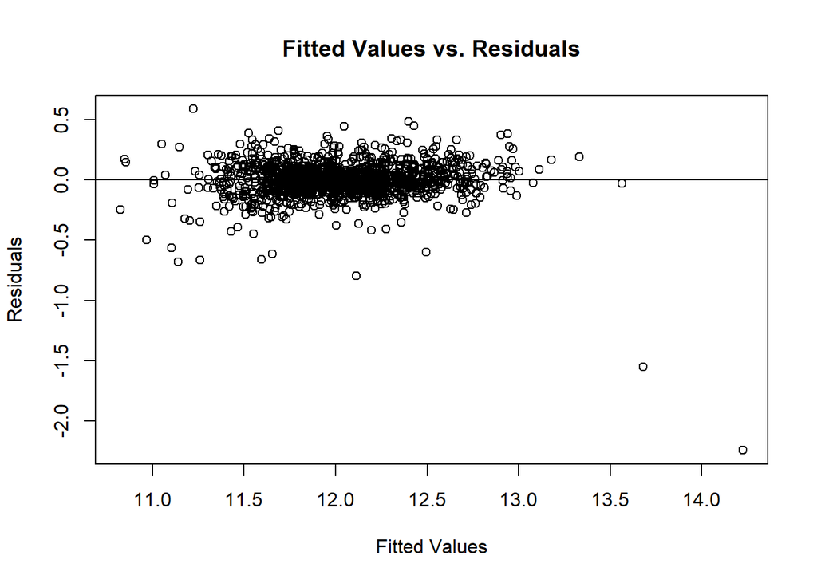

```r
plot(step_lm$fitted.values, step_lm$residuals,
     xlab="Fitted Values", ylab="Residuals", main="Fitted Values vs. Residuals")
abline(h=0)
```

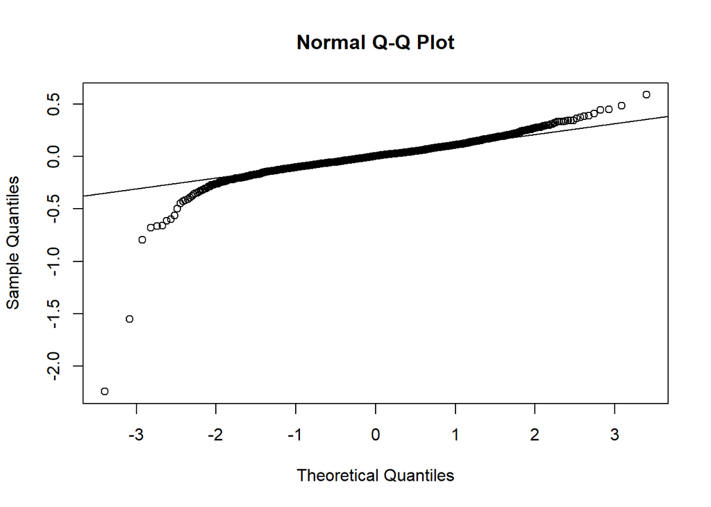

```r
qqnorm(step_lm$residuals); qqline(step_lm$residuals)
```

```r
# Predict prices for test data
pred_saleprice <- predict(step_lm, test)
# Convert from log back to real world number
pred_saleprice <- sapply(pred_saleprice, exp)
# Prepare data frame for submission
kaggle <- data.frame(Id=test$Id, SalePrice=pred_saleprice)
write.csv(kaggle, file = "submission.csv", row.names=FALSE)
```

#### Kaggle Submission

My Kaggle username is **simi0202**. My Score as of Dec 15 2019 is **0.13513**

The Submission Data is available on my github reposistory https://github.com/samriti0202/DATA-605/FINAL.

Thank you .